# MATH1115 PROJECT 2 Investigating International and Domestic Students’ Academic Attainment

Patrick Conroy (460385857)

Wednesday / 1PM / Carslaw 705-706 Computer Lab

# Sydney University

## IDA

*Source Data:* http://www.maths.usyd.edu.au/u/UG/JM/DATA1001/r/current/projects/IAPData/DATA1001_2019_S2C_PROJECT3_DATA_v2.csv

Again, this is sourced from the Sydney Institutional Analytics and Planning (IAP), with ethics permission and approval by the DVC (Education) Prof. Pip Pattison.

*Key Stakeholder:*

Our key stakeholder is the University of Sydney. It is pertinent to the university that its students—both domestic and international—achieve a high level of academic attainment, else the university’s graduates will be underqualified and the subsequent value of a University of Sydney degree may be perceived to be lower. This is directly relevant to the University of Sydney as if its degrees diminish in perceived value, less students will seek to enrol and the university will struggle to maintain high student enrollment numbers and profitability.

*Complexity of Data & Classification of Variables:*

```r
#setwd("~/Desktop/MATH1115")
proj2 <- read.csv("DATA1001_2019_S2C_PROJECT3_DATA_v2.csv")

dim(proj2)
#There are 10,845 data entries (or students listed) and twenty-six variables.

str(proj2)
#To view the structure of our dataset.

head(proj2)
#To view the first few columns of large data sets.

colnames(proj2)
#To determine names of all the variables.
```

## Exploring Data

**Research Question 1 (a): Are international students more likely to attain higher marks in their studies?**

```r
library(tidyverse)
```

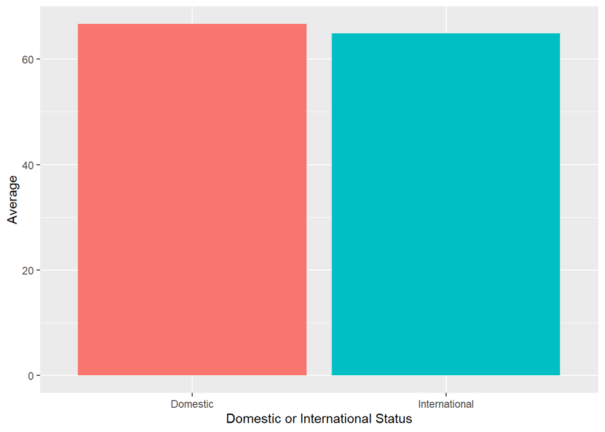

```r
#ggplot(data=proj2) + geom_bar(stat = 'count', aes(x = 'domestic...international.status'))

#ggplot(na.omit(proj2), aes(x = as.factor(Domestic...international.status), y = UoS.Mark)) + geom_col()

proj2 %>% group_by(Domestic...international.status) %>% summarise(Average = mean(UoS.Mark)) %>% ggplot(data = ., aes(x = Domestic...international.status, y = Average, fill = Domestic...international.status)) + xlab("Domestic or International Status") + geom_col(show.legend = F)
```

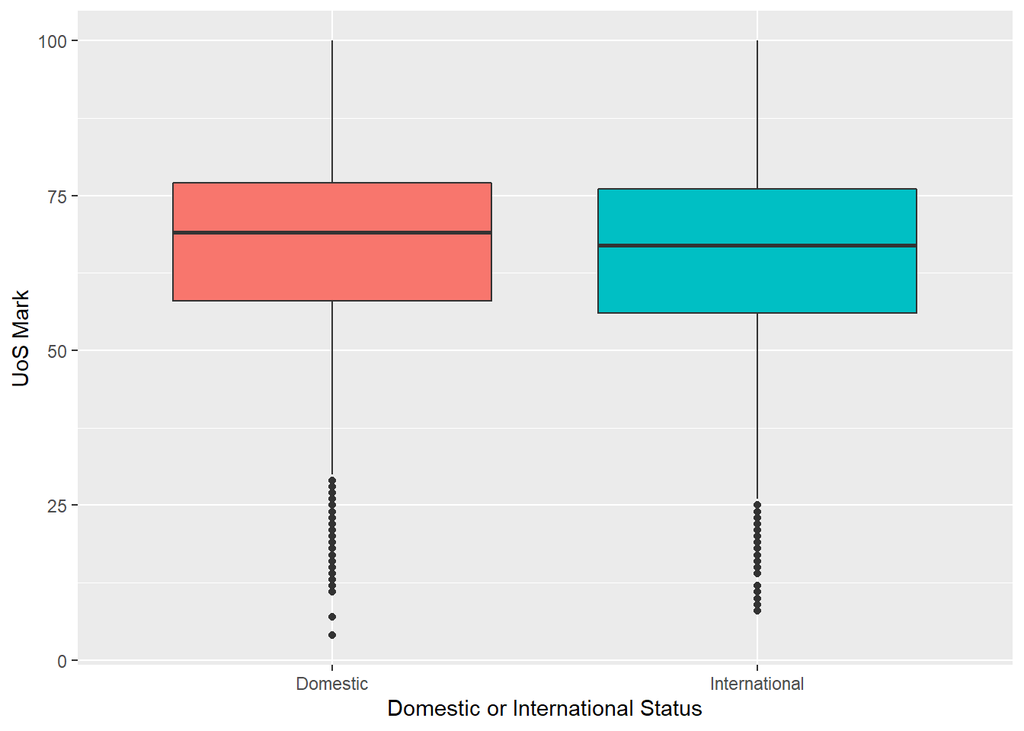

```r
ggplot(data = proj2, aes(x = Domestic...international.status, y = UoS.Mark, fill=Domestic...international.status)) + xlab("Domestic or International Status") + ylab("UoS Mark") + geom_boxplot(show.legend = FALSE)
```

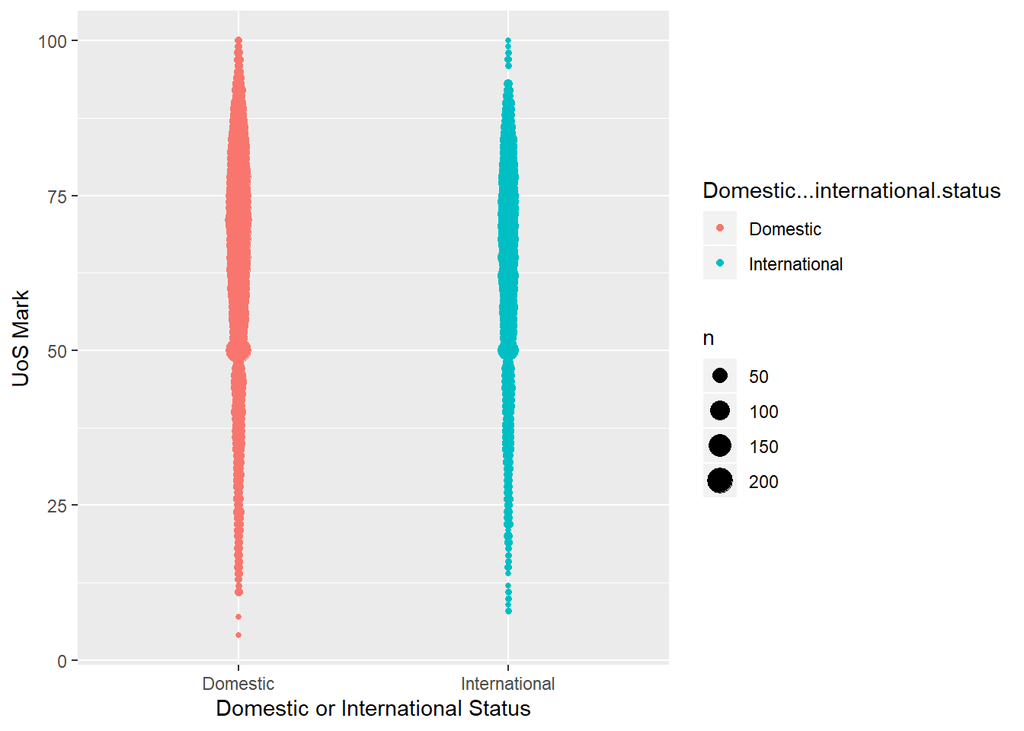

```r
#domestic = subset(proj2,Domestic...international.status=='Domestic')

ggplot(data = proj2, aes(x = Domestic...international.status, y = UoS.Mark, color=Domestic...international.status)) + xlab("Domestic or International Status") + ylab("UoS Mark") + geom_count()
```

```r
proj2 %>% group_by(Domestic...international.status) %>% summarise(Average = mean(UoS.Mark))
```

```
## # A tibble: 2 x 2
##   Domestic...international.status Average
##   <fct>                             <dbl>
## 1 Domestic                           66.7
## 2 International                      64.9
```

Key findings: Domestic students had a slightly higher average mark than international students at ~66.66, whereas International students had an average mark of ~64.92. We have concluded using ggplot that there is not a great discrepancy between the marks of Domestic and International students and their level of attainment is almost the same.

**Research Question 1. b) Is there a relationship between age and attainment for Domestic and International students, considering marginal difference in marks between the two?**

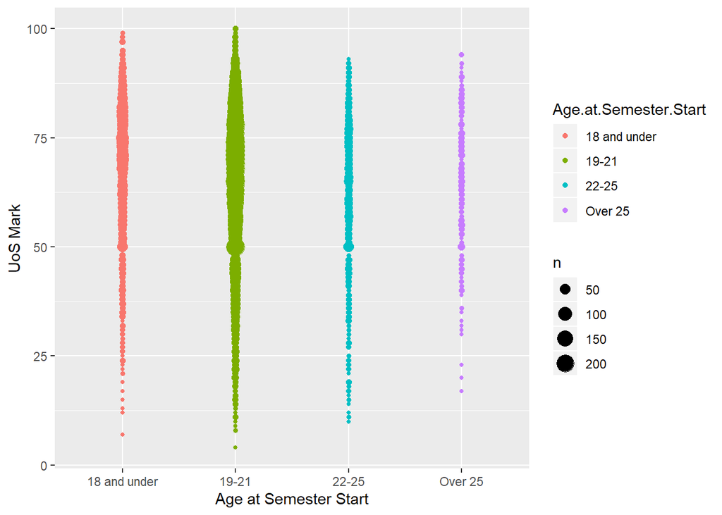

**Research Question 1. c) Check for correlation: is there a correlation between number of times Canvas was accessed in total and attainment for Domestic and International students?**

```r
Canvas.access.total = proj2$Canvas.access.Week.1+proj2$Canvas.access.Week.2+proj2$Canvas.access.Week.3+proj2$Canvas.access.Week.4+proj2$Canvas.access.Week.5+proj2$Canvas.access.Week.6+proj2$Canvas.access.Week.7+proj2$Canvas.access.Week.8+proj2$Canvas.access.Week.9+proj2$Canvas.access.Week.10+proj2$Canvas.access.Week.11+proj2$Canvas.access.Week.12+proj2$Canvas.access.Week.13+proj2$Canvas.access.Mid.semester.break+proj2$Canvas.access.STUVAC

t.test(Canvas.access.total, proj2$UoS.Mark, var.equal = T)
```

```
##
##  Two Sample t-test
##
## data:  Canvas.access.total and proj2$UoS.Mark
## t = -359.24, df = 21688, p-value < 2.2e-16
## alternative hypothesis: true difference in means is not equal to 0
## 95 percent confidence interval:
##  -51.75174 -51.19007
## sample estimates:
## mean of x mean of y
##  14.54053  66.01143
```

```r
ftable(proj2$UoS.Mark)
```

```
##    4   7   8   9  10  11  12  13  14  15  16  17  18  19  20  21  22  23  24  25  26  27  28  29  30  31  32  33  34  35  36  37  38  39  40  41  42  43  44  45  46  47  48  50  51  52  53  54  55  56  57  58  59  60  61  62  63  64  65  66  67  68  69  70  71  72  73  74  75  76  77  78  79  80 …
##
##    1   1   2   1   2   6   3   3   6   9   6   8   9  10  13  10  20  15  24  12  21  15  20  21  24  26  32  29  41  48  52  54  51  51  65  57  60  67  86  91  82  72  26 339 118 146 149 164 180 199 192 182 214 238 230 265 257 250 312 260 279 315 297 331 344 318 321 337 323 269 276 302 259 237 …
```

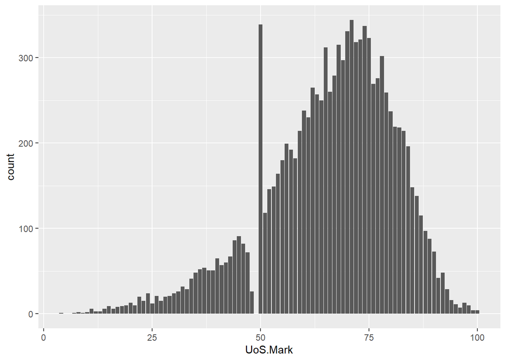

```r
ggplot(data = proj2, aes(x = UoS.Mark)) + geom_bar()
```

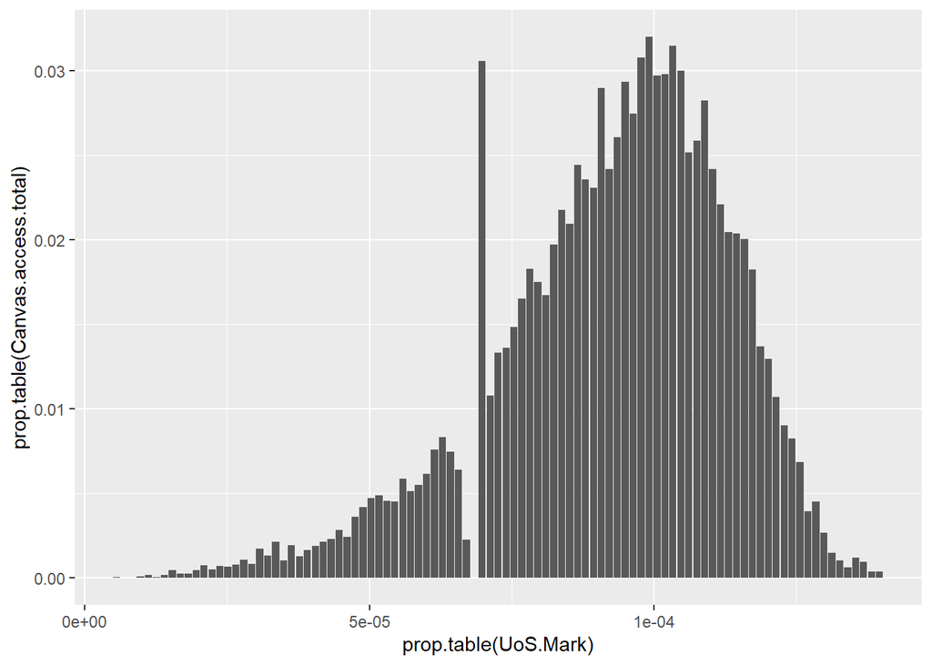

```r
#ggplot(data = proj2, aes(x = UoS.Mark, y = Canvas.access.total/prop.table(UoS.Mark))) + geom_col()

#proj2 %>% group_by(UoS.Mark) %>% summarise(Average = mean(Canvas.access.total)) %>% ggplot(data = ., aes(x = UoS.Mark, y = Average)) + geom_col()

ggplot(data = proj2, aes(x = prop.table(UoS.Mark), y = prop.table(Canvas.access.total))) + geom_col()
```

The outlier with students achieving marks of 50 is telling, and is probably due to rounding of marks for students near enough to 50—observe how there are zero marks of 49. Otherwise, this outlier would not exist.

```r
p = ggplot(data = proj2, aes(x = prop.table(UoS.Mark), y = prop.table(Canvas.access.total))) + geom_smooth() + xlab("UoS Mark proportionate") + ylab("Canvas Access proportionate")

L <- proj2 %>%
  lm(prop.table(Canvas.access.total) ~ prop.table(UoS.Mark), data = .)

L
```

```
##
## Call:
## lm(formula = prop.table(Canvas.access.total) ~ prop.table(UoS.Mark),
##     data = .)
##
## Coefficients:
##          (Intercept)  prop.table(UoS.Mark)
##            8.558e-05             7.190e-02
```

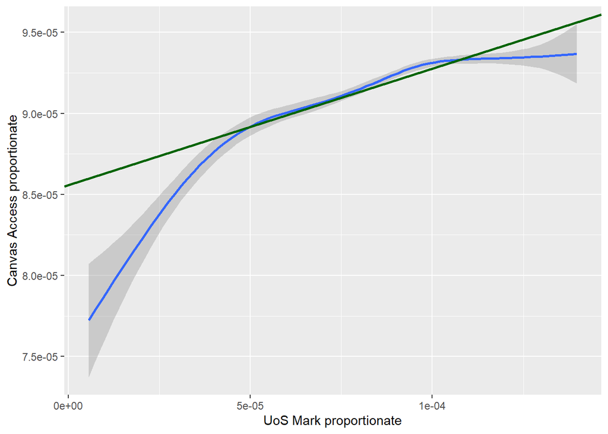

```r
p <- p + geom_abline(aes(intercept = 8.558e-05, slope = 7.190e-02), color = "darkgreen", size = 1)

p
```

Quite clearly, this is *not* a very good model for predicting Unit of Study mark from number of times Canvas has been accessed. Modelling this accurately would be difficult, even with a polynomial curve.

Research: http://theconversation.com/are-international-students-passing-university-courses-at-the-same-rate-as-domestic-students-116666

The findings are *very* similar to mine: “In 2016, international bachelor students failed 15% of all the subjects they attempted, compared to a 14% fail rate for domestic students. These are figures for commencing students, which means for the year they were admitted.”

“[T]he differences are not large.”

https://www.utas.edu.au/news/2017/11/16/454-research-shows-age-is-no-barrier-to-academic-success/